# Effects of ProsperLoan Characteristics on Its APR (Annual Percentage Rate)

## Dataset Overview

> This data set contains approximately 113,937 loan listings with 81 loan features. The features include loan amount, borrower's rate (or interest rate), current loan status, borrower income, prosperRating, debt-to-income ratio, listingCategory and others.

## Distribution of Borrower's APR

- *The borrower's APR in the prosper loan dataset has continuous values that range from 0.006530 to 0.512290 with 25%, 50%, and 75% of the data concetrated at the rate of 0.156290, 0.209760 and 0.283810 respectfively. Plotted with a standard scale, the distribution of borrower;s APR takes on a multimodal shape with a peak at 0.36.*

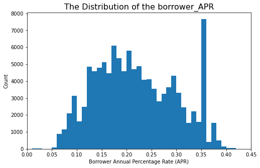

```python
# beginning with a standard-scaled plot
binsize = 0.01
bins = np.arange(0, prosperLoan_sub['borrowerAPR'].max()+binsize, binsize);

plt.figure(figsize=[8, 5])
plt.hist(data = prosperLoan_sub, x = 'borrowerAPR', bins = bins);
plt.xlabel('Borrower Annual Percentage Rate (APR)');
plt.ylabel('Count')
plt.title('The Distribution of the borrower_APR', fontsize = 16)
plt.xlim(0,0.45)
plt.show()
```

## The Distribution of Prosper Rating

- *Prosper rating has ordinal categorical values arange in order of increaing rating values - 'HR', 'E', 'D', 'C', 'B', 'A' and 'AA. plotted with countplot since it is categorical datatype. AA rating has the least count and C has the largest count.*

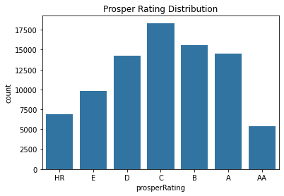

```python
# prosper rating countplot
base_color = sb.color_palette()[0]
rating_order = ['HR', 'E', 'D', 'C', 'B', 'A', 'AA']
sb.countplot(data = prosperLoan_sub, x = 'prosperRating', order = rating_order, color = base_color);
plt.title('Prosper Rating Distribution');
```

## The Distribution of Loan Amount

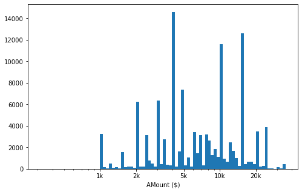

```python
# there's a long tail in the distribution, so let's put it on a log scale instead
log_binsize = 0.025
bins = 10 ** np.arange(2.5, np.log10(prosperLoan_sub['amount'].max())+log_binsize, log_binsize)
plt.figure(figsize=[8, 5])
plt.hist(data =prosperLoan_sub, x = 'amount', bins = bins)
plt.xscale('log')
plt.xticks([1e3, 2e3, 5e3, 1e4, 2e4], ['1k', '2k', '5k', '10k', '20k'])
plt.xlabel('AMount ($)')
plt.show()
```

## Loan Amount vs Borrower's APR

- *There is an approximately linear relationship produced between the loan amount plotted on a logarithmic scale and taking the original values of the borrower's APR. Below 5k, we have APR greater than 0.20 and above 15k, the APR is below 0.20. The two variables are negatively correlated based on the plot.*

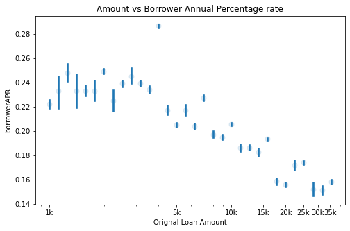

```python
# Regplot of loan original amount and the borrower APR
plt.figure(figsize=[8, 5])
log_binsize = 0.050
x_bins = 10 ** np.arange(2.5, np.log10(prosperLoan_sub['amount'].max())+log_binsize, log_binsize)
sb.regplot(data = prosperLoan_sub, x = 'amount', y ='borrowerAPR',x_bins = x_bins, scatter_kws = {'alpha':1/8}, fit_reg = False)
plt.xscale('log')
plt.xticks([1e3, 5e3, 1e4, 1.5e4, 2e4, 2.5e4, 3e4, 3.5e4],['1k', '5k', '10k', '15k','20k','25k', '30k', '35k'])
plt.xlabel('Orignal Loan Amount');
plt.title('Amount vs Borrower Annual Percentage rate')
plt.show()
```

## Prosper Rating vs Borrower's APR

- Plotting each prosper rating ordinal values against borrower's APR, we get approxiamtely normal distribution and we can see the effect of rating on the APR. the prosper rating 'AA' has the lowest APR, approxomately between 0.05 and 0.15 and has the lowest count (2500 and below). The 'HR' has the highest APR aproxiamtely between 0.3 and 0.4. With good prosper rating, one get lower borrower's APR.

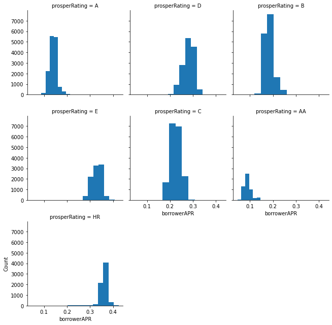

```python
# Plot illustrating the interval of borrowerAPR where prosper rating fits
g = sb.FacetGrid(data = prosperLoan_sub, col = 'prosperRating', col_wrap = 3);
g.map(plt.hist, 'borrowerAPR');
plt.ylabel('Count');
plt.show()
```

## Borrower's APR by Amount and Prosper Rating

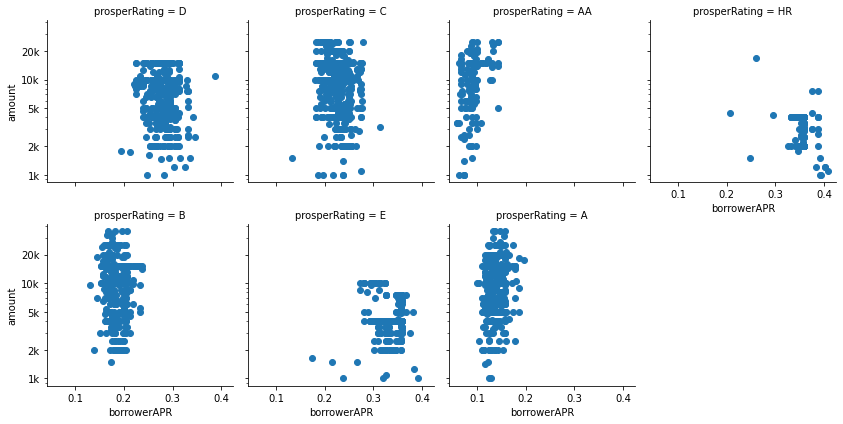

```python
# FacetGrid plot for three variables of interest
log_binsize1 = 0.050
plt.figure(figsize = [8, 5]);
bins = 10 ** np.arange(2.5, np.log10(prosperLoan_sub['amount'].max())+log_binsize, log_binsize1)
g = sb.FacetGrid(data = prosper_samp, col = 'prosperRating', size = 3, margin_titles = True,
                col_wrap = 4);
g.map(plt.scatter, 'borrowerAPR','amount');
plt.yscale('log');
plt.yticks([1e3, 2e3, 5e3, 1e4, 2e4], ['1k', '2k', '5k', '10k', '20k']);
```

## Borrower's APR by Debt-To-Income Ratio and Prosper Rating

- *Using color to produce this scatter plot, eventhough there aee some overlapping, we can see most of the borrower's APR below 0.2 to have smaller debt-to-income ratios while those that are above 0.35 have larger debt-to-income ratio. Again, a borrower with a good prosper rating has a lower borrower's APR is also suported by the plot.*

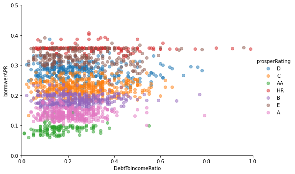

```python
#  Color encoding for 3 variables of interest
plt.figure(figsize = [10, 6])
g = sb.FacetGrid(data = prosper_samp, hue = 'prosperRating', size = 5, aspect = 1.5);
g.map(plt.scatter, 'DebtToIncomeRatio', 'borrowerAPR', alpha = 0.5);
plt.ylim(0,0.5);
plt.xlim(0, 1);
g.add_legend();
```